# Statistical Inference Course Project

Jin Yong Kim

25 October 2017

## Peer Graded Assignment: Statistical Inference Course Project

```r
setwd("C:/Test")
set.seed(19413)
```

## Part 1: Simulation Exercise Instructions

In this project you will investigate the exponential distribution in R and compare it with the Central Limit Theorem. The exponential distribution can be simulated in R with rexp(n, lambda) where lambda is the rate parameter. The mean of exponential distribution is 1/lambda and the standard deviation is also 1/lambda. Set lambda = 0.2 for all of the simulations. You will investigate the distribution of averages of 40 exponentials. Note that you will need to do a thousand simulations.

## Show the sample mean and compare it to the theoretical mean distribution

```r
n <- 40
Simulations <- 1000
Lambda <- 0.2

SampleMean <- NULL
for(i in 1:Simulations) {
  SampleMean <- c(SampleMean, mean(rexp(n, Lambda)))
}
mean(SampleMean)
```

```
## [1] 4.978479
```

So, as we can see, compared to the theoretical mean distribution of 5 , our mean 5 is close.

The theoretical standard deviation of the distribution is also 1/lambda , which, for a lambda of 0.2 , equates to 5 . The variance is the square of the standard deviation, which is 25.

```r
Variance <- var(SampleMean)
```

## Show that the distribution is appoximately normal

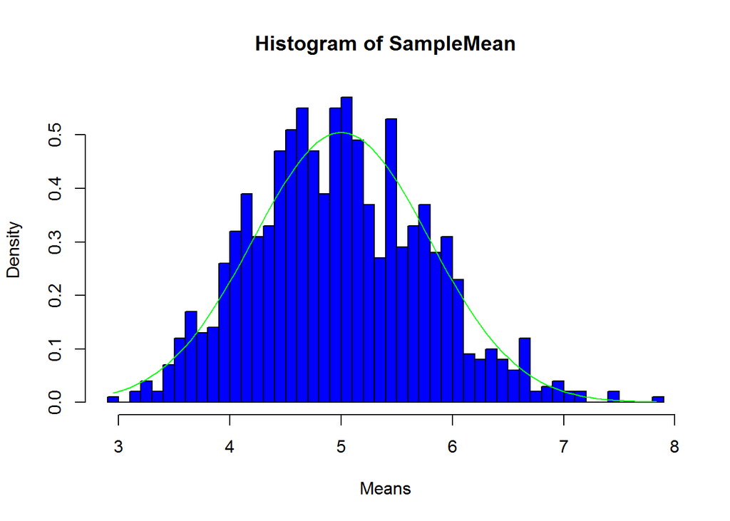

```r
hist(SampleMean, breaks = n, prob = T, col = "blue", xlab = "Means")
x <- seq(min(SampleMean), max(SampleMean), length = 100)
lines(x, dnorm(x, mean = 1/Lambda, sd = (1/Lambda/sqrt(n))), pch = 25, col = "green")
```

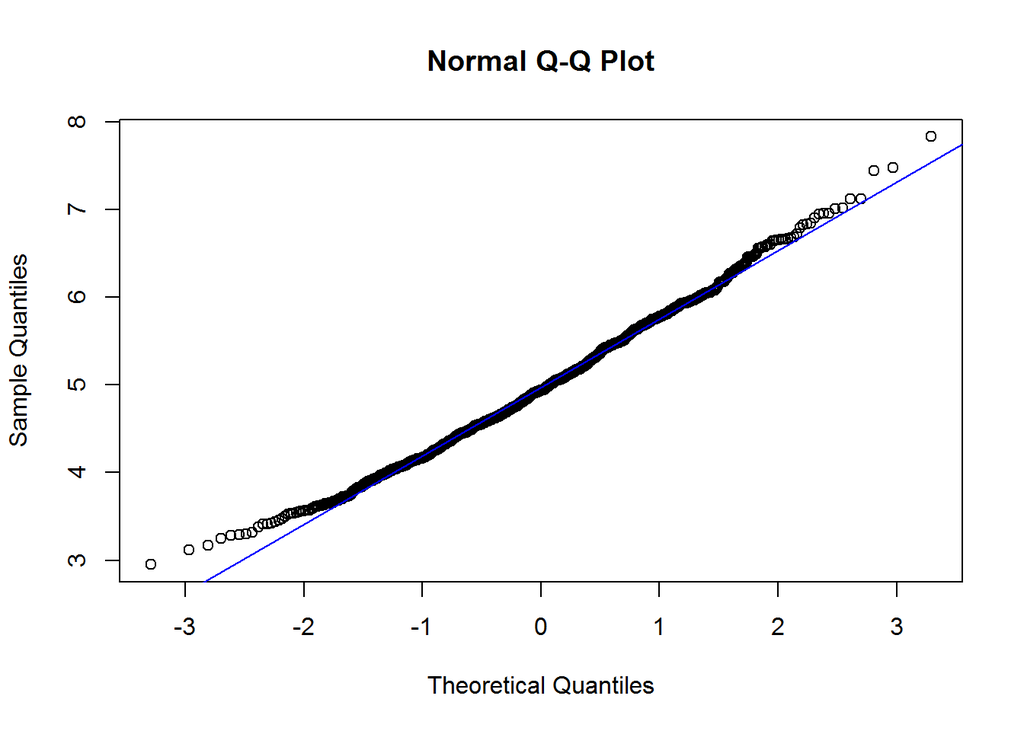

```r
qqnorm(SampleMean)
qqline(SampleMean, col = "blue")
```